# Corpula_Celltype

# 1. Use a number of correlation methods to find dependencies among the generated data.

# 2. Try to find data that has contrast dependency measures (i.e., high pearson but low distance correlation)

# 3. The goal of simulation is to show that none of the 10 dependency measures aren’t perfect; does not answer all.

# 4. If I cannot find the interesting pattern as I did over the summer,

# 4-1. I could improve on the generated data above by manually chaning the covariance of variables in the mat.

# 4-2. Adding more variables could resolve the issue with some changes. (Mostly L-shaped or one cluster that has no signal)

# 4-3. All three clusters have no signals.

# 4-4. Two of the clusters have no signals, third has a signal but negligible one.

# 5. The number of variables for the final simulation is 20.

# Push more often into the git so that I have a back-up in github.

# Make a function that takes the data and automatically gives the heatmaps of 10 different dependency measures with/without absolute values.

# 2. Dependence Measures

## 2-1. Pearson’s correlation coefficient (Linearity)

```r
cor_pearson_mat <- stats::cor(gen_dat, method = "pearson")

cor_pearson_mat[upper.tri(cor_pearson_mat, diag = T)] <- NA
cor_pearson_mat[1:5,1:5]
```

```
##            [,1]       [,2]       [,3]      [,4] [,5]
## [1,]         NA         NA         NA        NA   NA
## [2,] -0.4467285         NA         NA        NA   NA
## [3,]  0.1080677 -0.2376997         NA        NA   NA
## [4,]  0.5259168 -0.0403900 -0.3949026        NA   NA
## [5,]  0.8604543 -0.4623507  0.2522477 0.4277865   NA
```

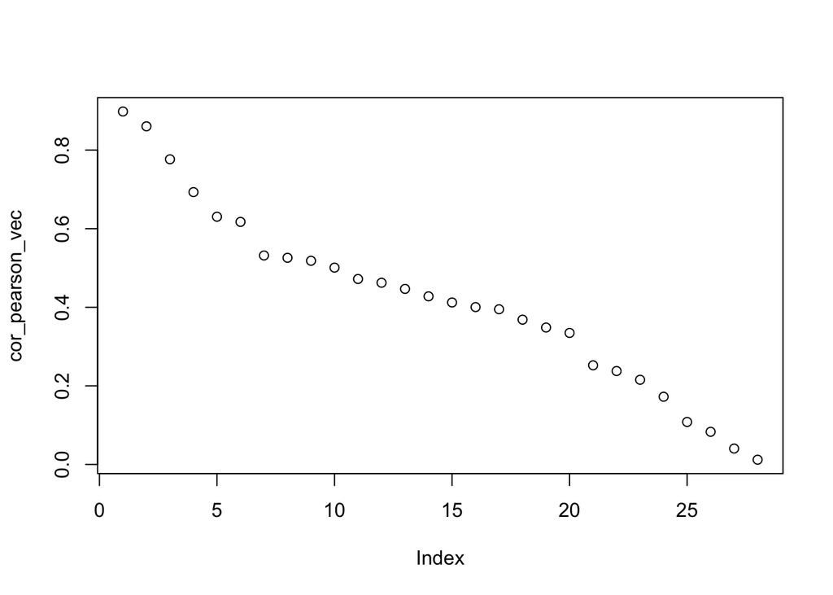

```r
# plot the correlations
cor_pearson_vec <- sort(abs(cor_pearson_mat), decreasing = T)
plot(cor_pearson_vec)
```

## 2-2. Spearman’s correlation coefficient (Monotone)

```r
cor_spearman_mat <- stats::cor(gen_dat, method = "spearman")

cor_spearman_mat[upper.tri(cor_spearman_mat, diag = T)] <- NA
cor_spearman_mat[1:5,1:5]
```

```
##            [,1]       [,2]       [,3]      [,4] [,5]
## [1,]         NA         NA         NA        NA   NA
## [2,] -0.5786894         NA         NA        NA   NA
## [3,]  0.2403934 -0.2160899         NA        NA   NA
## [4,]  0.2185778  0.1081304 -0.5110561        NA   NA
## [5,]  0.8779039 -0.5817865  0.3452113 0.1317322   NA
```

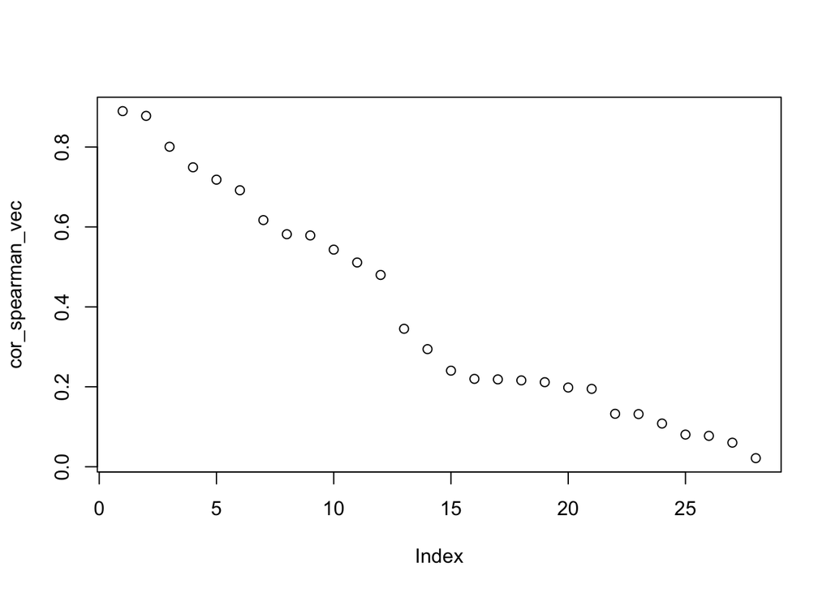

```r
# plot the correlations
cor_spearman_vec <- sort(abs(cor_spearman_mat), decreasing = T)
plot(cor_spearman_vec)
```

## 2-3. Kendall’s correlation coefficient, τ (Monotone)

```r
cor_kendall_mat <- stats::cor(gen_dat, method = "kendall")

cor_kendall_mat[upper.tri(cor_kendall_mat, diag = T)] <- NA
cor_kendall_mat[1:5,1:5]
```

```
##            [,1]        [,2]       [,3]       [,4] [,5]
## [1,]         NA          NA         NA         NA   NA
## [2,] -0.3645691          NA         NA         NA   NA
## [3,]  0.1621002 -0.16115431         NA         NA   NA
## [4,]  0.1195030  0.07648898 -0.3244890         NA   NA
## [5,]  0.6818277 -0.36623647  0.2231503 0.07342685   NA
```

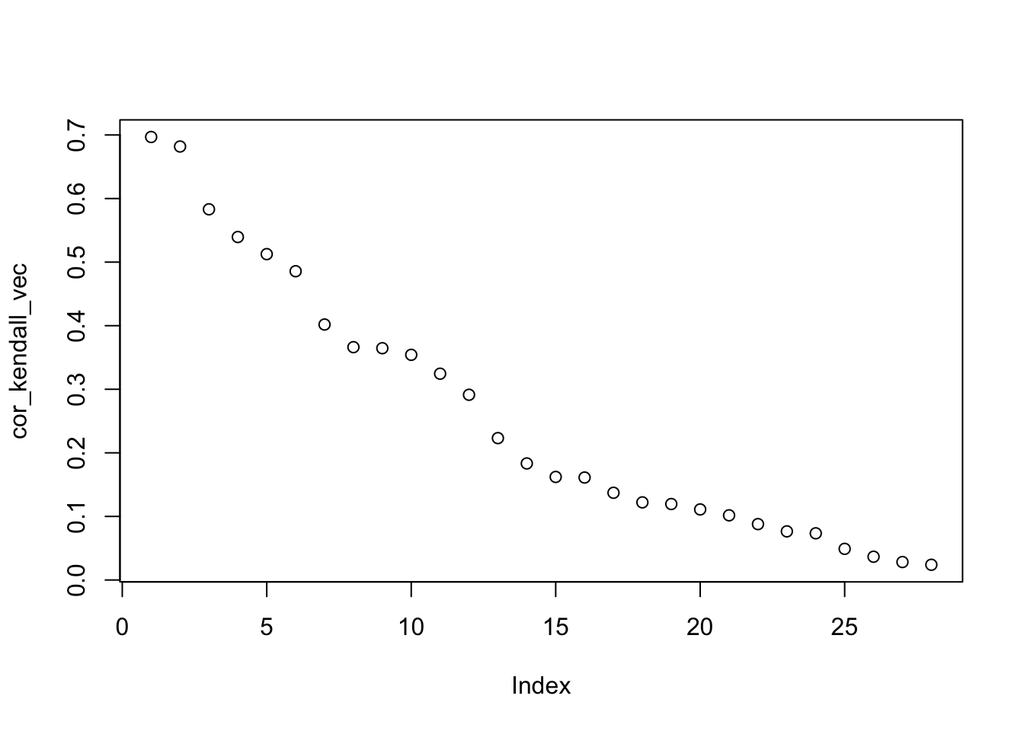

```r
# plot the correlations
cor_kendall_vec <- sort(abs(cor_kendall_mat), decreasing = T)
plot(cor_kendall_vec)
```

## 2-4. Distance correlation (Non-linear)

```r
library(energy)

cor_dist_mat <- matrix(nrow = ncol(gen_dat), ncol = ncol(gen_dat))

for (i in 2:ncol(gen_dat)){
  for (j in 1:(i-1)){
    cor_dist_mat[i,j] <- dcor2d(as.numeric(gen_dat[, i]), as.numeric(gen_dat[, j]))
  }
}

cor_dist_mat[upper.tri(cor_dist_mat, diag = T)] <- NA
cor_dist_mat[1:5,1:5]
```

```
##            [,1]       [,2]       [,3]      [,4] [,5]
## [1,]         NA         NA         NA        NA   NA
## [2,] 0.35416767         NA         NA        NA   NA
## [3,] 0.06170987 0.15465803         NA        NA   NA
## [4,] 0.30307060 0.07396532 0.30429923        NA   NA
## [5,] 0.74244384 0.37193911 0.09605867 0.2134077   NA
```

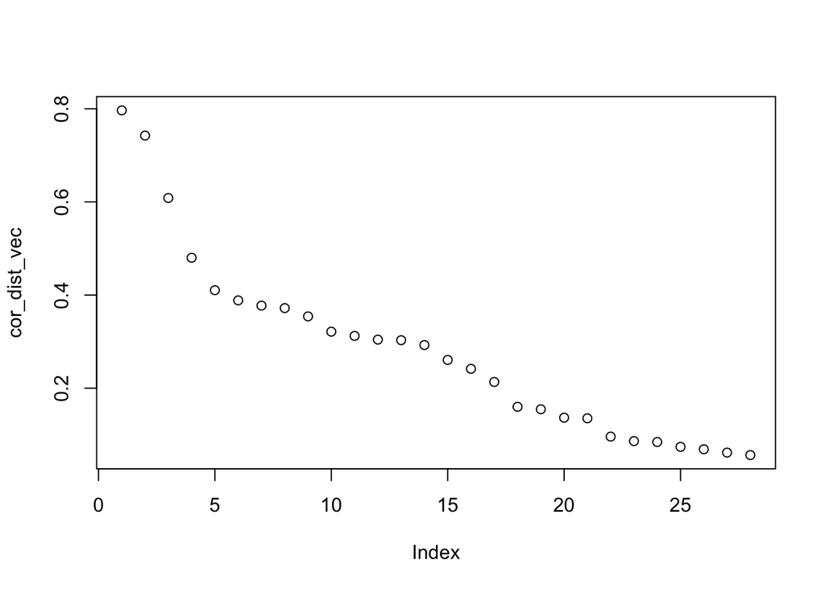

```r
cor_dist_vec <- sort(abs(cor_dist_mat), decreasing = T)
plot(cor_dist_vec)
```

## 2-5. Hoeffding’s D measure (Distance)

```r
library(Hmisc)
hoeff_dist <- hoeffd(x = as.matrix(gen_dat))

cor_hoeffd_mat <- hoeff_dist$D

cor_hoeffd_mat[upper.tri(cor_hoeffd_mat, diag = T)] <- NA
```

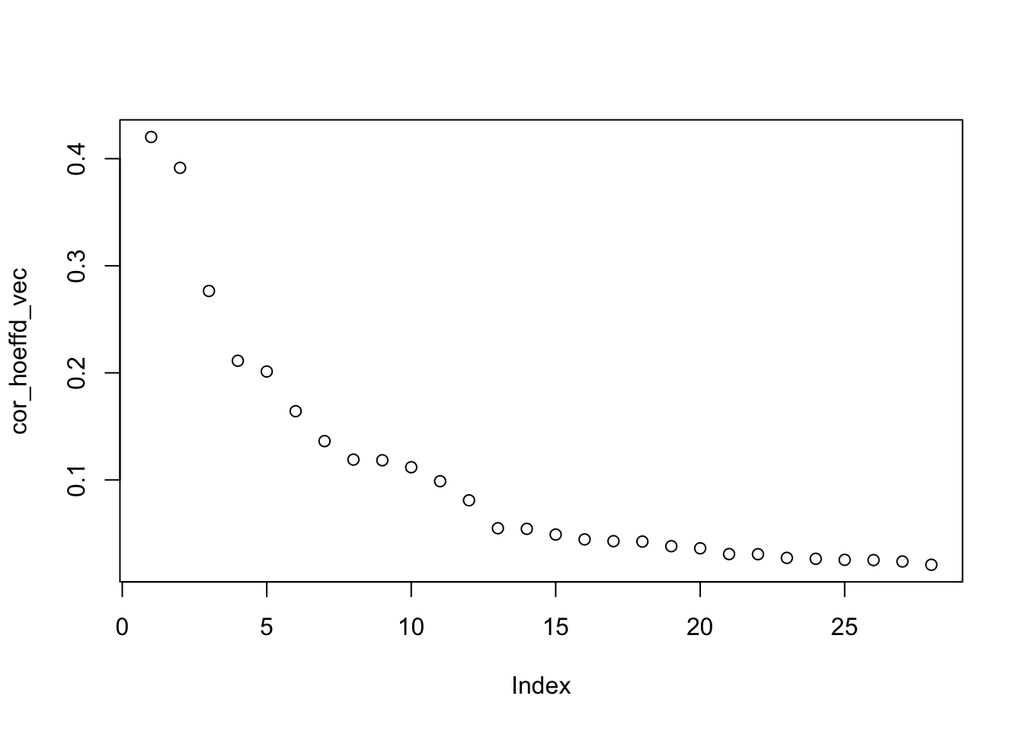

```r
cor_hoeffd_vec <- sort(abs(cor_hoeffd_mat), decreasing = T)
plot(cor_hoeffd_vec)
```

## 2-6. Mutual information (MI) (information)

```r
library(entropy)

cor_MI_mat <- matrix(nrow = ncol(gen_dat), ncol = ncol(gen_dat))

for (i in 2:ncol(gen_dat)){
  for (j in 1:(i-1)){
    y2d <- discretize2d(as.matrix(gen_dat[, i]),
                        as.matrix(gen_dat[, j]),
                        numBins1 = 20,
                        numBins2 = 20)
    cor_MI_mat[i,j] <- as.numeric(mi.empirical(y2d))
  }
}
```

[output not shown]

[output cut: 19 more lines]

[output not shown]

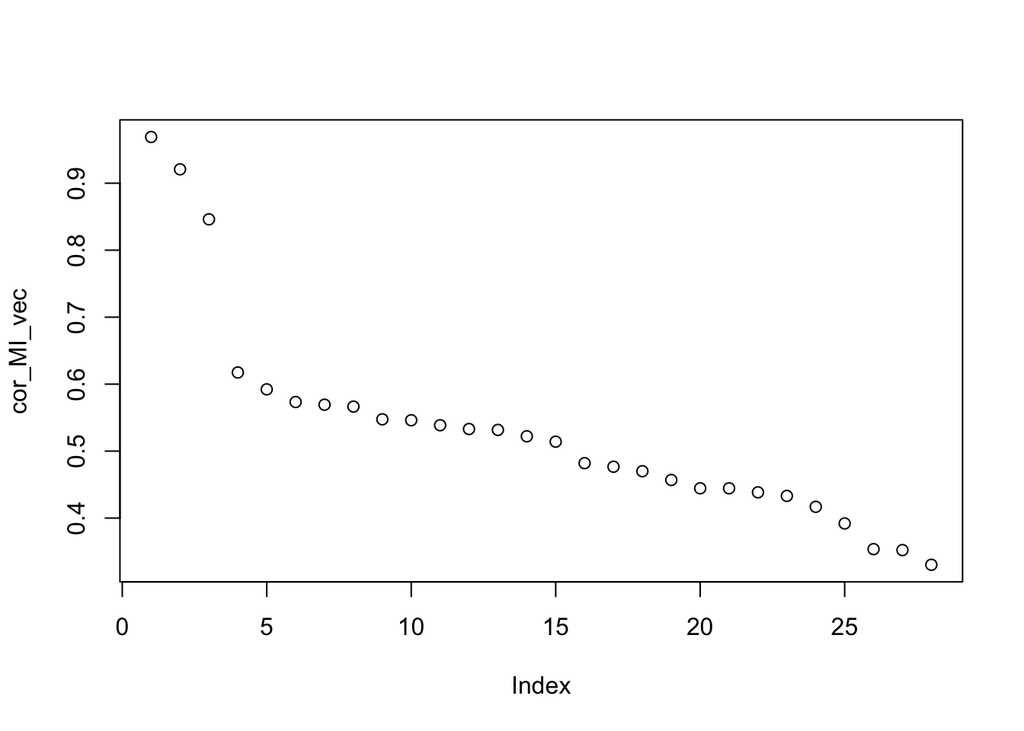

```r
cor_MI_vec <- sort(abs(cor_MI_mat), decreasing = T)
plot(cor_MI_vec)
```

## 2-7. Maximum Information Coefficient (MIC) (information)

```r
library(minerva)

cor_MIC <- mine(gen_dat)
cor_MIC_mat <- cor_MIC$MIC

cor_MIC_mat[upper.tri(cor_MIC_mat, diag = T)] <- NA
```

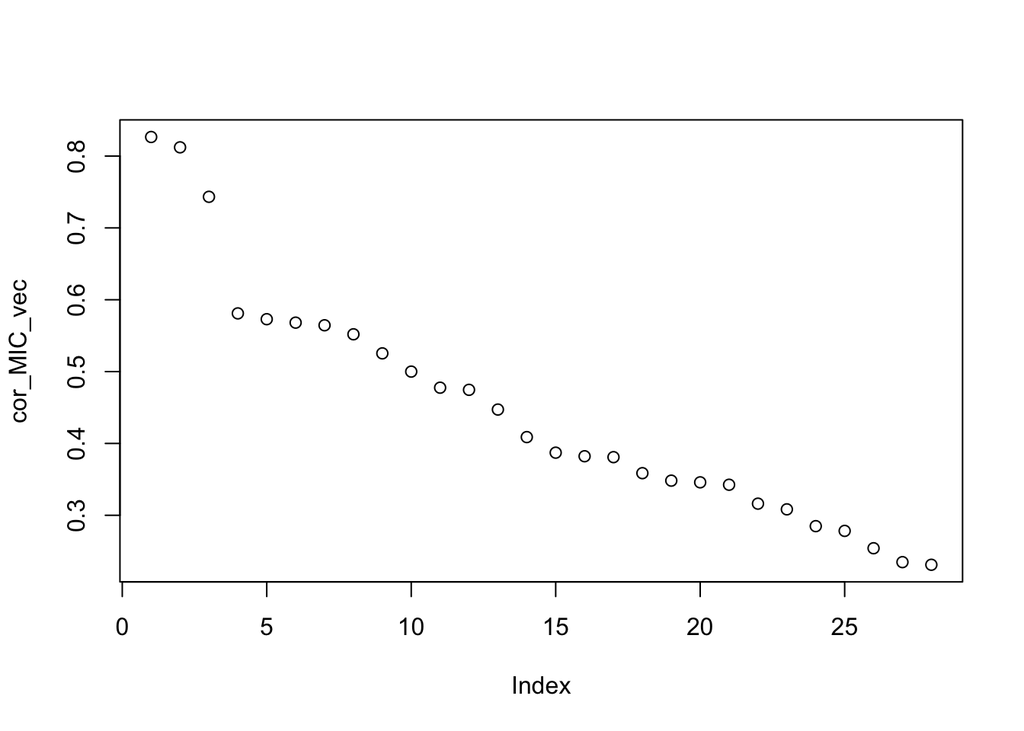

```r
cor_MIC_vec <- sort(cor_MIC_mat, decreasing = T)
plot(cor_MIC_vec)
```

## 2-8. Chatterjee’s method

```r
library(XICOR)

cor_XI_mat <- matrix(nrow = ncol(gen_dat), ncol = ncol(gen_dat))

for (i in 2:ncol(gen_dat)){
  for (j in 1:(i-1)){
    cor_XI_mat[i,j] <- calculateXI(as.numeric(gen_dat[, i]), as.numeric(gen_dat[, j]))
  }
}

cor_XI_mat[upper.tri(cor_XI_mat, diag = T)] <- NA
```

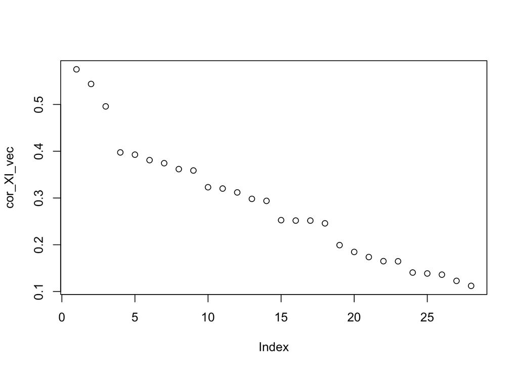

```r
cor_XI_vec <- sort(abs(cor_XI_mat), decreasing = T)
plot(cor_XI_vec)
```

## 2-9. Hilbert Schmidt Independence Criterion (HSIC)

- Disregard this coefficient

```r
library(dHSIC)

cor_HSIC_mat <- matrix(nrow = ncol(gen_dat), ncol = ncol(gen_dat))

for (i in 2:ncol(gen_dat)){
  for (j in 1:(i-1)){
    cor_HSIC_mat[i,j] <- dhsic(as.numeric(gen_dat[, i]),
                               as.numeric(gen_dat[, j]))$dHSIC
  }
}

cor_HSIC_mat[upper.tri(cor_HSIC_mat, diag = T)] <- NA
```

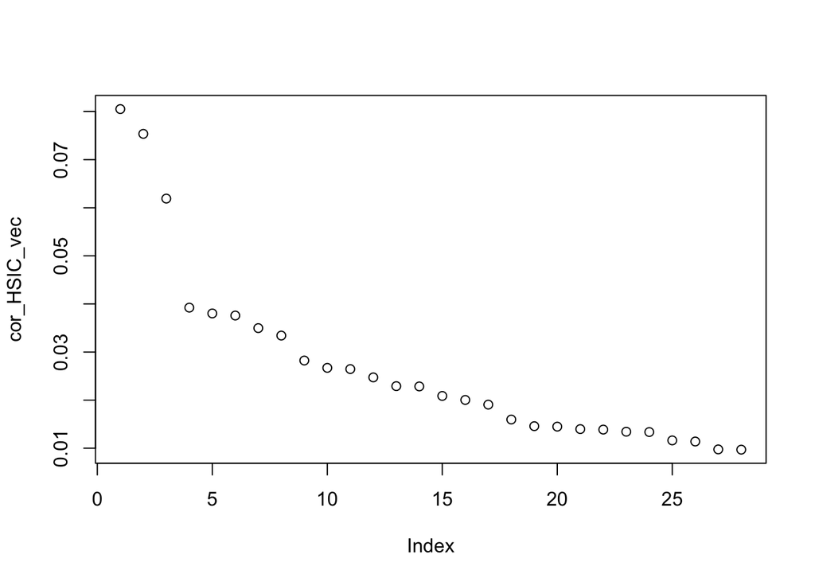

```r
cor_HSIC_vec <- sort(abs(cor_HSIC_mat), decreasing = T)
plot(cor_HSIC_vec)
```

## 2-10. Blomqvist’s Beta

```r
library(VineCopula)

cor_blomqvist_mat <- BetaMatrix(gen_dat)

cor_blomqvist_mat[upper.tri(cor_blomqvist_mat, diag = T)] <- NA
cor_blomqvist_mat[1:5,1:5]
```

```
##        [,1]   [,2]   [,3]  [,4] [,5]
## [1,]     NA     NA     NA    NA   NA
## [2,] -0.260     NA     NA    NA   NA
## [3,]  0.188 -0.136     NA    NA   NA
## [4,]  0.160  0.340 -0.284    NA   NA
## [5,]  0.688 -0.316  0.220 0.104   NA
```

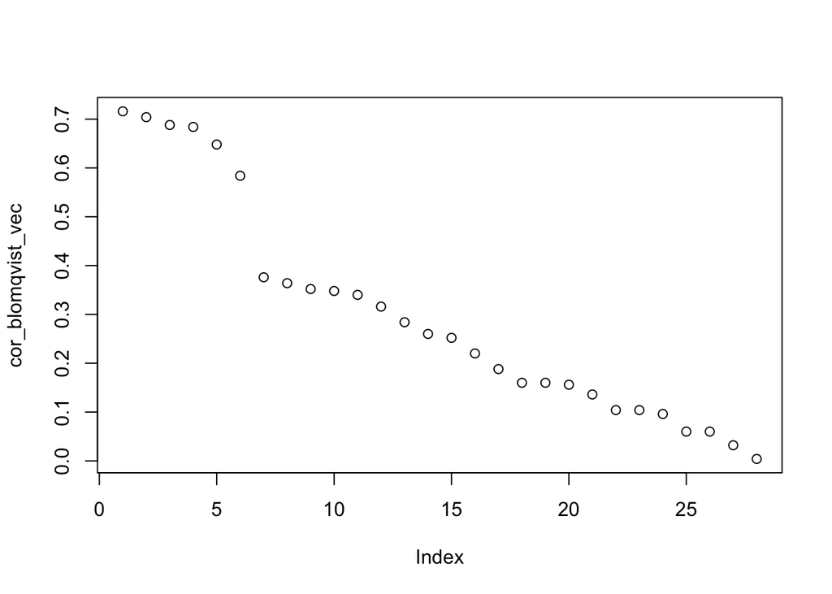

```r
cor_blomqvist_vec <- sort(abs(cor_blomqvist_mat), decreasing = T)
plot(cor_blomqvist_vec)
```

# 3. Find contrast characteristics among the correlation coefficients above

## 3-1-1. low pearson (<0.50) and high spearman (>0.5) (linearity vs monotone)

```r
cor_contrast1 <- (abs(cor_pearson_mat) < 0.5) & (abs(cor_spearman_mat) > 0.5)
cor_contrast_ind1 <- which(cor_contrast1, arr.ind = T)
nrow(cor_contrast_ind1)
```

```
## [1] 5
```

## 3-1-2. Visualization of low pearson (<0.50) and high spearman (>0.5) (linearity vs monotone)

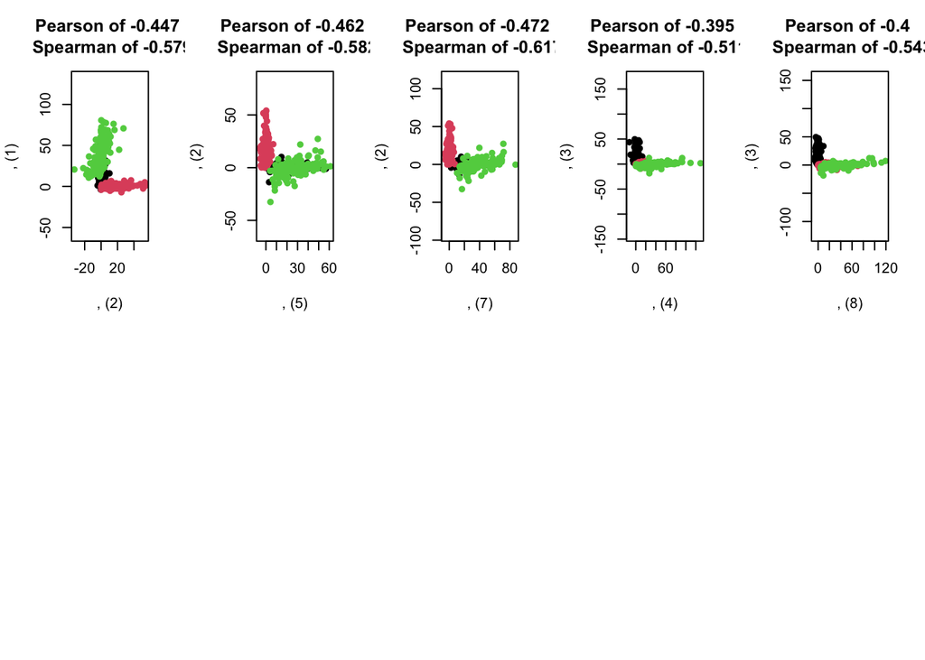

```r
par(mfrow = c(2, 5))
for (i in 1:nrow(cor_contrast_ind1)){
   index1 <- cor_contrast_ind1[i, 1]; index2 <- cor_contrast_ind1[i, 2]
   plot(gen_dat[,index1], gen_dat[,index2], col = gen_label, asp = T,
      pch = 16, xlab = paste0(colnames(gen_dat)[index1], ", (", index1, ")"),
      ylab = paste0(colnames(gen_dat)[index2], ", (", index2, ")"),
      main = paste(paste0("Pearson of ", round(cor_pearson_mat[index1, index2], 3)),
                   "\n",
                   paste0("Spearman of ", round(cor_spearman_mat[index1, index2], 3))))
}
```

## 3-2-1. high pearson (>0.5) and low spearman (<0.3) (linearity vs monotone)

```r
cor_contrast2 <- (abs(cor_pearson_mat) > 0.5) & (abs(cor_spearman_mat) < 0.3)
cor_contrast_ind2 <- which(cor_contrast2, arr.ind = T)
nrow(cor_contrast_ind2)
```

```
## [1] 4
```

## 3-2-2. Visualization of high pearson (>0.5) and low spearman (<0.3) (linearity vs monotone)

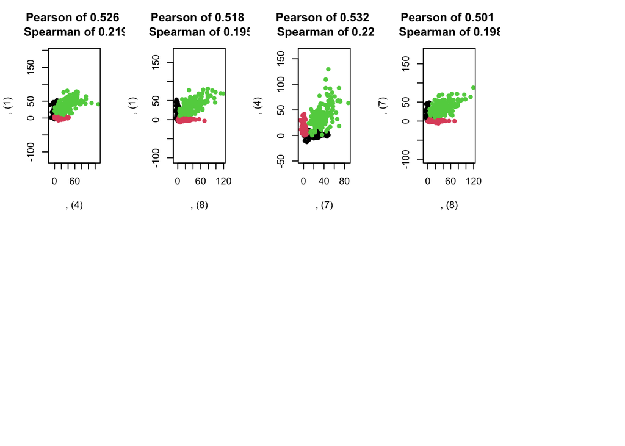

```r
par(mfrow = c(2, 5))
for (i in 1:nrow(cor_contrast_ind2)){
   index1 <- cor_contrast_ind2[i, 1]; index2 <- cor_contrast_ind2[i, 2]
   plot(gen_dat[,index1], gen_dat[,index2], col = gen_label, asp = T,
      pch = 16, xlab = paste0(colnames(gen_dat)[index1], ", (", index1, ")"),
      ylab = paste0(colnames(gen_dat)[index2], ", (", index2, ")"),
      main = paste(paste0("Pearson of ", round(cor_pearson_mat[index1, index2], 3)),
                   "\n",
                   paste0("Spearman of ", round(cor_spearman_mat[index1, index2], 3))))
}
```

## 3-3-1. high pearson (>0.50) and low distance correlation (<0.40) (linearity vs Non-linearity)

```r
cor_contrast3 <- (abs(cor_pearson_mat) > 0.5) & (abs(cor_dist_mat) < 0.4)
cor_contrast_ind3 <- which(cor_contrast3, arr.ind = T)
nrow(cor_contrast_ind3)
```

```
## [1] 5
```

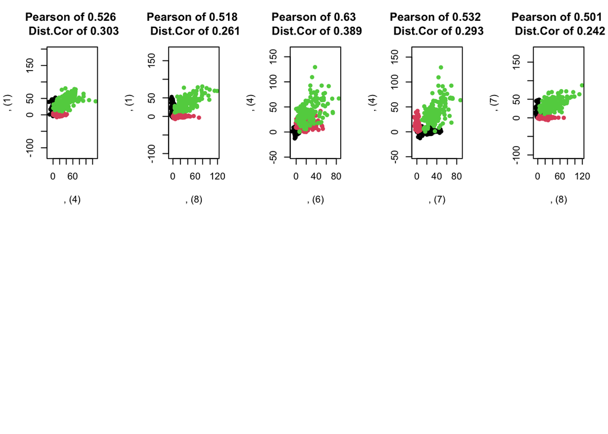

```r
par(mfrow = c(2, 5))

for (i in 1:nrow(cor_contrast_ind3)){
   index1 <- cor_contrast_ind3[i, 1]; index2 <- cor_contrast_ind3[i, 2]
   plot(gen_dat[,index1], gen_dat[,index2], col = gen_label, asp = T,
      pch = 16, xlab = paste0(colnames(gen_dat)[index1], ", (", index1, ")"),
      ylab = paste0(colnames(gen_dat)[index2], ", (", index2, ")"),
      main = paste(paste0("Pearson of ", round(cor_pearson_mat[index1, index2], 3)),
                   "\n",
                   paste0("Dist.Cor of ", round(cor_dist_mat[index1, index2], 3))))
}
```

```r
cor_contrast4 <- (abs(cor_pearson_mat) < 0.5) & (abs(cor_dist_mat) > 0.5)
cor_contrast_ind4 <- which(cor_contrast4, arr.ind = T)
nrow(cor_contrast_ind4)
```

```
## [1] 0
```

## 3-5-1. low pearson (< 0.5) and high MIC (> 0.5) (linearity vs Information)

```r
cor_contrast5 <- (abs(cor_pearson_mat) < 0.5) & (abs(cor_MIC_mat) > 0.5)
cor_contrast_ind5 <- which(cor_contrast5, arr.ind = T)
nrow(cor_contrast_ind5)
```

```
## [1] 4
```

## 3-5-2. Visualization of low pearson (< 0.5) and high MIC (> 0.5) (linearity vs Information)

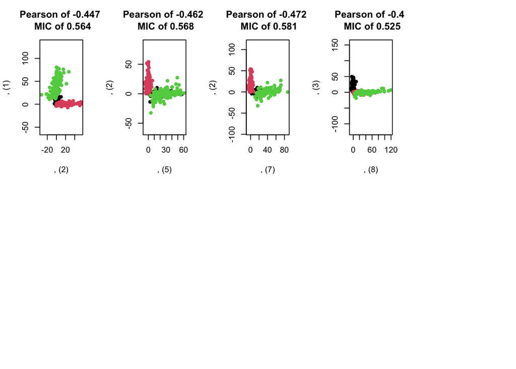

```r
par(mfrow = c(2, 5))

for (i in 1:nrow(cor_contrast_ind5)){
   index1 <- cor_contrast_ind5[i, 1]; index2 <- cor_contrast_ind5[i, 2]
   plot(gen_dat[,index1], gen_dat[,index2], col = gen_label, asp = T,
      pch = 16, xlab = paste0(colnames(gen_dat)[index1], ", (", index1, ")"),
      ylab = paste0(colnames(gen_dat)[index2], ", (", index2, ")"),
      main = paste(paste0("Pearson of ", round(cor_pearson_mat[index1, index2], 3)),
                   "\n",
                   paste0("MIC of ", round(cor_MIC_mat[index1, index2], 3))))
}
```

## 3-6-1. High pearson (> 0.5) and low MIC (< 0.4) (linearity vs Information)

```r
cor_contrast6 <- (abs(cor_pearson_mat) > 0.5) & (abs(cor_MIC_mat) < 0.4)
cor_contrast_ind6 <- which(cor_contrast6, arr.ind = T)
nrow(cor_contrast_ind6)
```

```
## [1] 3
```

## 3-6-2. Visualization of High pearson (> 0.5) and low MIC (< 0.4) (linearity vs Information)

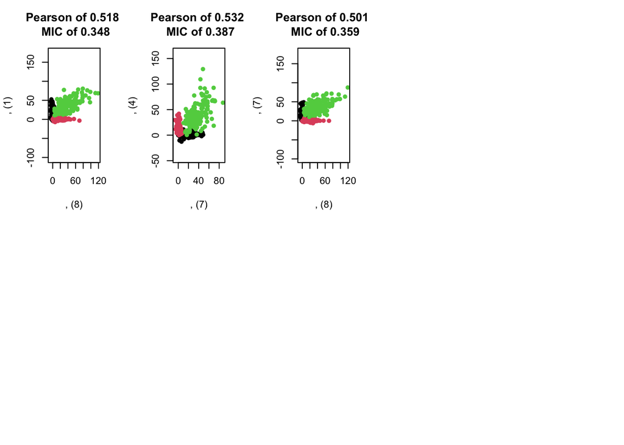

```r
par(mfrow = c(2, 5))

for (i in 1:nrow(cor_contrast_ind6)){
   index1 <- cor_contrast_ind6[i, 1]; index2 <- cor_contrast_ind6[i, 2]
   plot(gen_dat[,index1], gen_dat[,index2], col = gen_label, asp = T,
      pch = 16, xlab = paste0(colnames(gen_dat)[index1], ", (", index1, ")"),
      ylab = paste0(colnames(gen_dat)[index2], ", (", index2, ")"),
      main = paste(paste0("Pearson of ", round(cor_pearson_mat[index1, index2], 3)),
                   "\n",
                   paste0("MIC of ", round(cor_MIC_mat[index1, index2], 3))))
}
```